# noaproject1

## Flanker-Simon Study

I completed this project for Dalhousie's NESC 3505: Neural Data Science course. The course and the instructions were written and taught by Dr. Aaron Newman. In the following assignment, I worked with behavioural data from a "flanker-Simon" experiment. The experiment was conducted in Dr. Aaron Newman's NeuroCognitive Imaging Lab at Dalhousie University, was ran by Ella Dubinsky and Lisa Beck, and was designed and programmed by PhD student Mike Lawrence. This experiment combined two tasks: the flanker and Simon effects. We wanted to see if there was an interaction between the flanker and Simon effects in this study (suggesting overlapping processes), or if they show additivity (indicative of separate processes).

I completed this project with Anna Torres, Ashraf Samir Ahmed, Chantel Findlay, Tess Konwisarz, and Thomas Pope. Together, we were able to:

[x] Read in data from all of the participants in the study.

[x] Clean data: remove missing data, practice trials, and outliers.

[x] Perform EDA on the data.

[x] Visualize data

[x] Extract meaning from data

[x] Perform a statistical test to test hypotheses.

[x] Answer the research question

```python
# Filter os files for the list of data files
from glob import glob
import pandas as pd
import numpy as np
import matplotlib.pyplot as plt
import seaborn as sns

# Statistical testing packages
import statsmodels.api as sm
from statsmodels.formula.api import ols
from scipy import stats
```

## Read in the data

The naming convention for this data set was `[subjectID]_[date]_[time]`, with the date represented as YYYY_MM_DD and the time (when the experiment was started) as HH_MM. The sub-directory contains three files, all named with the naming convention above, but with different extensions. The three files are:

- `[ID]_code.py` - the python file that presented the stimuli and collected responses
- `[ID]_data.txt` - the data file we want to open
- `[ID]_trigger.txt` - an additional data file not of interest to us

```python
# Get a list of data files names
filenames = glob('spid*/spid*_data.txt')
```

```python
# Reading in the data file for each participant.
df = pd.concat([pd.read_csv(filename, sep='\t') for filename in filenames])
```

## Clean the data

```python
# removing redundant lines and dropping any rows containing missing data
df = df.drop_duplicates().dropna()
```

## Remove Practice Trials

```python
#removing practice trials
df = df[df.block != 'practice']

# Transform rt to millis
df.rt = df.rt * 1000
```

## Outliers Treatment

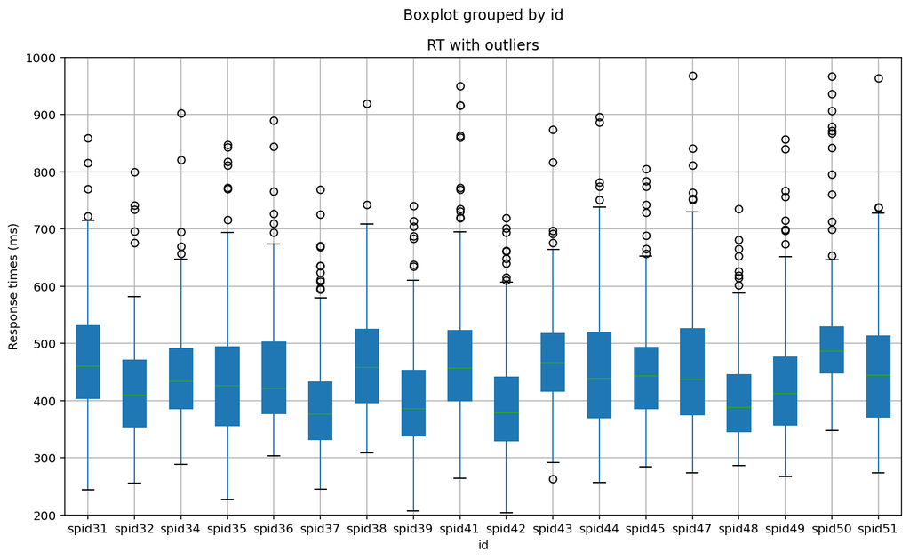

```python
# Plot to inspect the participants data before outliers treatment
bplots= df[df.error == False].boxplot(by='id', column=['rt'], grid=True, patch_artist=True)

plt.title('RT with outliers')
plt.ylim(200, 1000)
plt.ylabel('Response times (ms)')
plt.show()
```

**Fig.1: Response time (ms) for each participant (n=18)**

## Removing Outliers

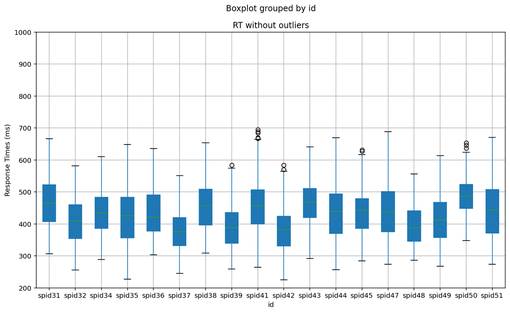

```python
## Create a grouping to calculate the mean and std per individual
df_grouped = df[df.error ==False][['id','rt']].groupby(['id']).agg(
rt_mean=('rt','mean'),
	rt_std=('rt','std'),
)

## Calculate the thresholds outside of which the response times are considered outliers
df_grouped['rt_max'] = df_grouped['rt_mean'] + (df_grouped['rt_std'] * 2)
df_grouped['rt_min'] = df_grouped['rt_mean'] - (df_grouped['rt_std'] * 2)

## Merge the dataframe to simplify filtering of outliers
df = pd.merge(df, df_grouped, on=['id'])

## Replace all outliers with the mean rt
df['rt'] = df[df.error == False].apply(
    lambda row: row['rt_mean'] if (row.rt < row.rt_min or row.rt > row.rt_max) else row['rt'],
    axis=1
)

## Inspecting the data for proper handling
df[df.error == False].boxplot(by='id', column=['rt'], grid=True, patch_artist=True)
plt.title('RT without outliers')
plt.ylabel('Response Times (ms)')
plt.ylim(200, 1000)
plt.show()
```

**Fig.2: Response time (ms) for each participant (n=18), without outliers (±2 standard deviations at the individual subject level)**

## Derive and encode Simon condition

The data here was originally stored in a way where it has a column indicating if the flankers were congruent or not, but it does not have a column that tells us whether each trial was congreuent or not for the Simon task component. In the following code, we created a new column in the DataFrame, called "Simon". This new column will tell us whether each trial was Simon-congruent or Simon-incongruent.

```python
# First we create a set of conditions — in our cases, the different possible mappings
conditions = [
    (df['mapping'] == 0) & (df['target'] == 'black') & (df['targetLocation'] == 'left'),
    (df['mapping'] == 0) & (df['target'] == 'black') & (df['targetLocation'] == 'right'),
    (df['mapping'] == 0) & (df['target'] == 'white') & (df['targetLocation'] == 'left'),
    (df['mapping'] == 0) & (df['target'] == 'white') & (df['targetLocation'] == 'right'),
    (df['mapping'] == 1) & (df['target'] == 'black') & (df['targetLocation'] == 'left'),
    (df['mapping'] == 1) & (df['target'] == 'black') & (df['targetLocation'] == 'right'),
    (df['mapping'] == 1) & (df['target'] == 'white') & (df['targetLocation'] == 'left'),
    (df['mapping'] == 1) & (df['target'] == 'white') & (df['targetLocation'] == 'right')
    ]

# The mappings below align with the order of the entries in the conditions list above
mapping = ['incompatible',
           'compatible',
           'compatible',
           'incompatible',
           'compatible',
           'incompatible',
           'incompatible',
           'compatible'
          ]

# This line creates a new column called "simon" based on the conditions and mapping lists above
df['Simon'] = np.select(conditions, mapping, default='none')
```

#### Error analysis

```python
# Calculate the accuracy per Simon trial per flankers condition. To do the analysis for all factors, flip the error column so that when we take the mean, we get accuracy rate because
# accuracy_rate = 1 - mean(errors)

df['correct'] = 1-df['error'].astype(int)
df_grouped_errors = df.groupby(['flankers', 'Simon']).agg(
condition_mean=('rt','mean'),
condition_std=('rt','std'),
condition_accuracy_rate=('correct', 'mean')
)

df_grouped_errors.style.set_precision(2)
```

| flankers | Simon | condition_mean | condition_std | condition_accuracy_rate |
| --- | --- | --- | --- | --- |
| congruent | compatible | 394.08 | 78.85 | 0.97 |
|  | incompatible | 419.89 | 73.42 | 0.94 |
| incongruent | compatible | 449.86 | 85.26 | 0.88 |
|  | incompatible | 465.64 | 68.89 | 0.89 |

**Table 1: Mean response time (ms), standard deviation (ms), and accuracy rate for each condition**

## Exploratory Data Analysis

#### Skewness Inspection

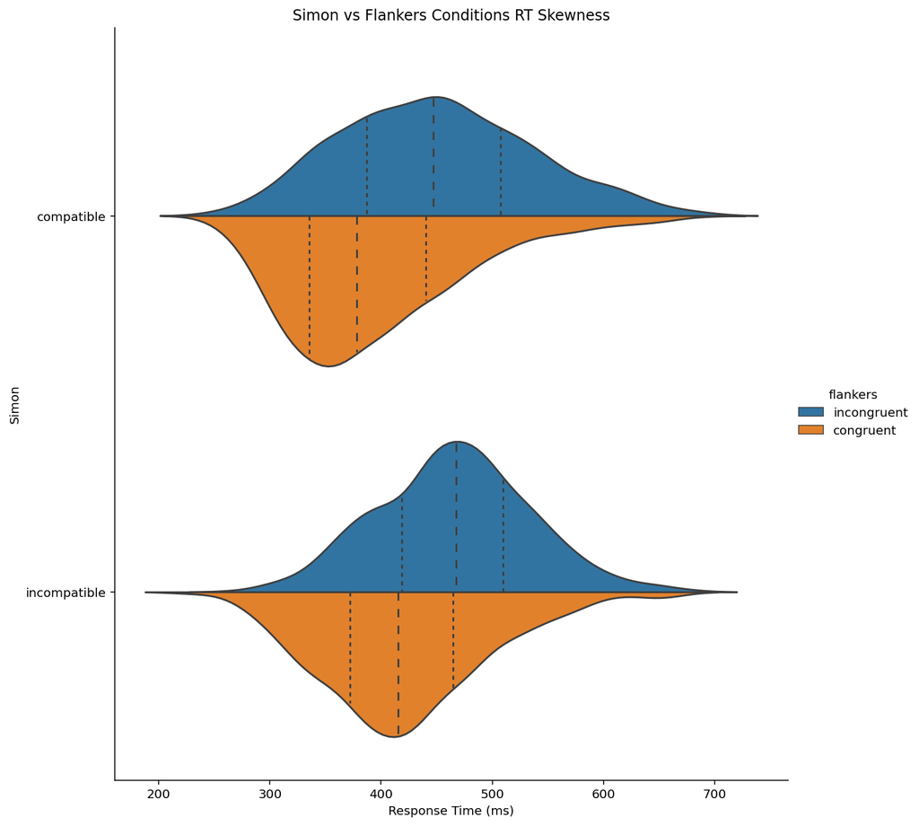

```python
# Inspecting skewness and symmetry
sns.catplot(x="rt", y="Simon", hue="flankers",
            kind="violin", split=True, height=9, inner='quartile',
            data=df[df.error == False])

plt.title('Simon vs Flankers Conditions RT Skewness')
plt.xlabel('Response Time (ms)')
plt.show()
```

**Fig. 3: Skewness in Simon Trials, by Flanker Conditions**

#### Comparing means

By comparing the means in the different conditions, we can observe visible differences between the four conditions. From the boxplot in Figure 4, we can see visible differences between the four different conditions. Most of the effects appear to be related to the relative means but not to the spread of the data.

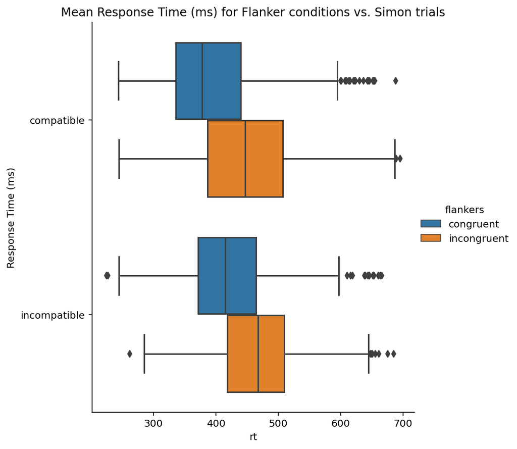

```python
axis = sns.catplot(x="rt", y="Simon", hue="flankers", kind="box", data=df[df.error == False], height=6, hue_order=['congruent', 'incongruent'])
axis.set(title='Mean Response Time (ms) for Flanker conditions vs. Simon trials')
axis.set(ylabel='Response Time (ms)')
plt.show()
```

**Fig.4: Mean response time (ms) comparing flanker congruent-incongruent conditions for Simon compatible-incompatible trials**

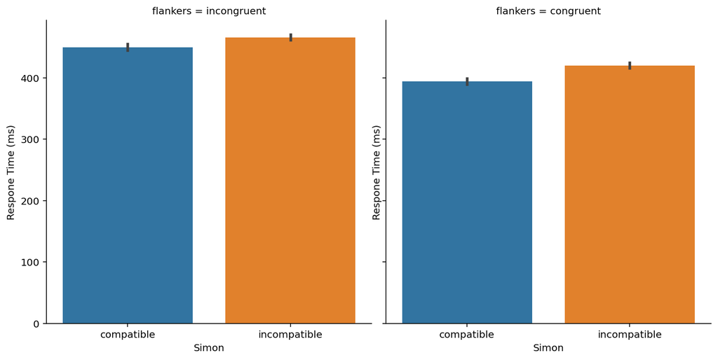

```python
axis = sns.catplot(kind='bar', y="rt", x="Simon", col='flankers', data=df[df.error == False]
    , hue_order=['congruent', 'incongruent'],
    )
axis.set(ylabel='Respone Time (ms)')
plt.show()
```

**Fig.5: Mean response time (ms) comparing flanker congruent-incongruent conditions for Simon compatible-incompatible trials**

#### Error Analysis

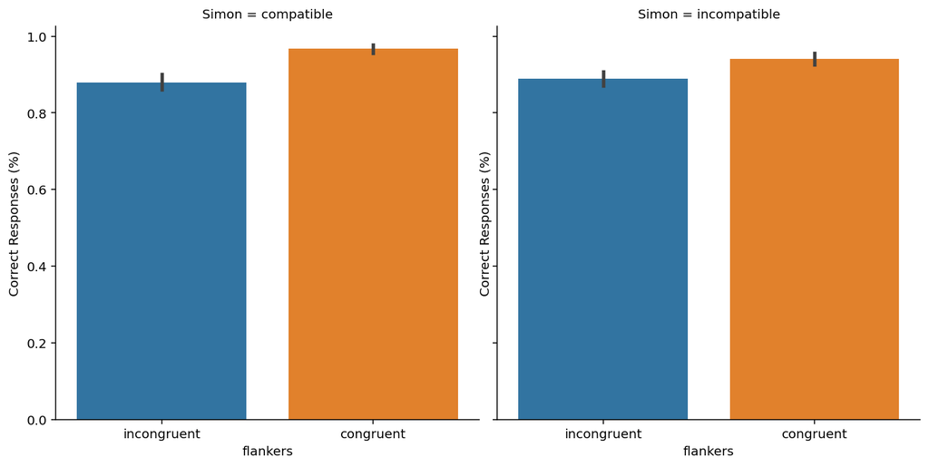

```python
axis = sns.catplot(kind='bar', x="flankers", y="correct", col='Simon', data=df)
axis.set(ylabel='Correct Responses (%)')
plt.show()
```

**Fig.6: Accuracy rate comparing flanker congruent-incongruent conditions for Simon compatible-incompatible trials**

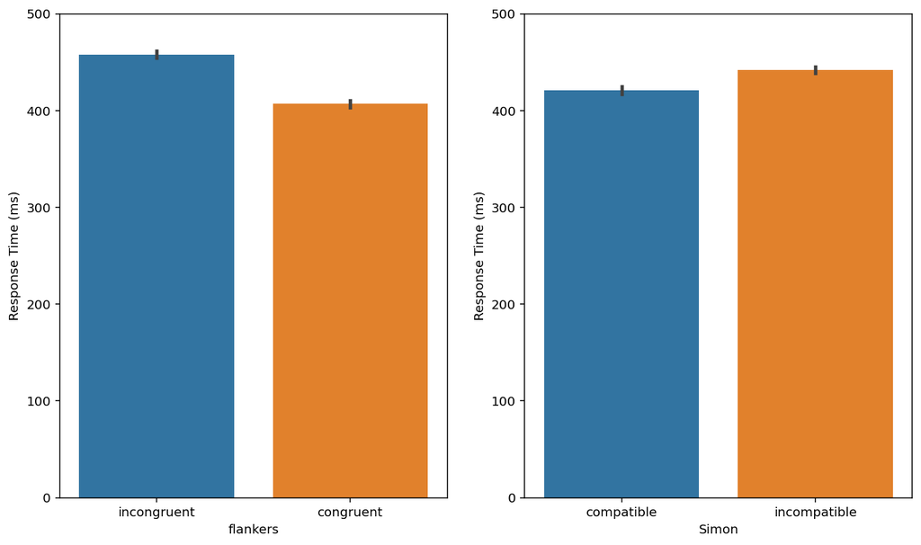

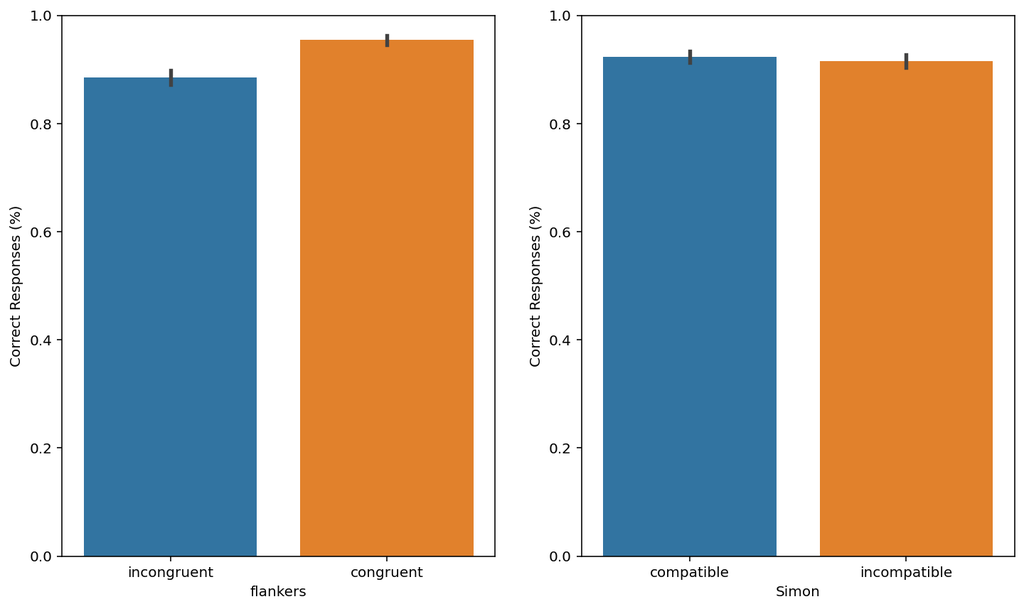

```python
f, axes = plt.subplots(1, 2)
axis = sns.barplot(x="flankers", y="rt", data=df, ax=axes[0])
axis.set(ylabel='Response Time (ms)', ylim=[0,500])

axis = sns.barplot(x="Simon", y="rt", data=df, ax=axes[1])
axis.set(ylabel='Response Time (ms)', ylim=[0,500])

f, axes = plt.subplots(1, 2)
axis = sns.barplot(x="flankers", y="correct", data=df, ax=axes[0])
axis.set(ylabel='Correct Responses (%)', ylim=[0,1])

axis = sns.barplot(x="Simon", y="correct", data=df, ax=axes[1])
axis.set(ylabel='Correct Responses (%)', ylim=[0,1])
plt.show()
```

**Fig. 7: Response times (ms) and correct responses (%) for Simon trials (compatible, incompatible) and flankers conditions (congruent, incongruent), separately**

### Task: Perform a statistical test to test the hypotheses.

We performed a two-way Analysis of Variances (ANOVA) to test for any significant differences between the means of the trials using Simon and Flankers as factors. The two-way ANOVA test was justified because we are comparing 2 factors (Simon and Flankers) and are interested in whether or not there are any differences in the means between the groups. We performed two two-way ANOVA tests, one for the impact of Simon and flankers variants on the response time, and another on the impact of these conditions on accuracy rate.

```python
model = ols(formula='rt ~ C(Simon) + C(flankers) + C(Simon):C(flankers)', data=df[df.error == False])
res = model.fit()
sm.stats.anova_lm(res, typ=2).style
```

|  | sum_sq | df | F | PR(>F) |
| --- | --- | --- | --- | --- |
| C(Simon) | 416897.892412 | 1.000000 | 70.651293 | 0.000000 |
| C(flankers) | 2441985.335389 | 1.000000 | 413.840955 | 0.000000 |
| C(Simon):C(flankers) | 23832.082017 | 1.000000 | 4.038800 | 0.044536 |
| Residual | 22358063.707145 | 3789.000000 | nan | nan |

**Table 2: Two-way ANOVA test for Simon effect, flankers effect, and interaction of the effects, for reaction times (ms)**

```python
mod = ols(formula='correct ~ C(Simon) + C(flankers) + C(Simon):C(flankers)', data=df)
res = mod.fit()
sm.stats.anova_lm(res, typ=2).style
```

|  | sum_sq | df | F | PR(>F) |
| --- | --- | --- | --- | --- |
| C(Simon) | 0.066849 | 1.000000 | 0.916282 | 0.338509 |
| C(flankers) | 5.027373 | 1.000000 | 68.909182 | 0.000000 |
| C(Simon):C(flankers) | 0.302853 | 1.000000 | 4.151151 | 0.041670 |
| Residual | 300.726699 | 4122.000000 | nan | nan |

**Table 3: Two-way ANOVA test for Simon effect, flankers effect, and interaction of the effects, for accuracy rate**

### Conclusion:

Is there an interaction between the flanker and Simon effects in this study (suggesting overlapping processes), or do they show additivity (indicative of separate processes)?

Based on our EDA results, on Simon-compatible trials, the average response time for flanker-congruent stimuli is 394.08 ms, (SD = 78.85 ms) and the average response time for flanker-incongruent stimuli is 449.86 ms (SD = 85.26 ms). On Simon-incompatible trials, the average response time for flanker-congruent stimuli is 419.89 ms (SD = 73.42 ms) and the average response time for flanker-incongruent stimuli is 465.64 ms (SD = 68.89 ms). Thus, the flanker-compatibility effect is 55.78 ms (449.86 ms – 394.08 ms), and the Simon-compatibility effect is 25.81 ms (419.89 ms – 394.08 ms). If the two effects in this study are independent from one another, the response times in the flanker incongruent- Simon incompatible condition should be at least 81.59 ms (55.78 ms + 25.81 ms) slower than in the congruent-compatible condition. In the example above, the flankers incongruent- Simon incompatible condition has a mean response time of 465.64 ms which is only 71.56 ms slower than the congruent-compatible condition (394.08 ms). This would suggest that the flanker and Simon effects interact, having less-than-additive RTs in the flankers incongruent-Simon incompatible condition, as 71.56 ms is less than the sum of the two separate effects (81.59 ms).

After looking at the ANOVA table, at the normal threshold of *p* < 0.05, the interaction effect is in fact shown to be significant.

Return to [homepage](https://noamaianski.github.io/portfolio/)